# Task 1 - Statistical Methods Project - Vo Van Viet, Khong Minh Duc, Cao Ngoc Bao Long

Exercise 5.8

Firstly, we assign the sample size, sample standard deviation, sample mean and the confidence level

```r
n=15            #sample size
s=12.5          #sample standard deviation
ybar=7.2        #sample mean
alpha <- 0.01   #assign the confidence level
```

Next, we compute the lower and the upper of the interval

```r
t.halfalpha= qt(p=1-(alpha/2),df=n-1) #compute t of half alpha and df
E=t.halfalpha*s/sqrt(n)               #compute margin of error
lower= ybar-E                         #calculate the lower of the interval
upper= ybar+E                         #calculate the upper of the interval
```

```r
cat("confidence interval: between",lower ,"and", upper )
```

```
## confidence interval: between -2.407719 and 16.80772
```

Exercise 5.9:

Firstly, we assign the sample size, sample standard deviation, sample mean and the confidence level

```r
n=200           #sample size
s=1.3           #sample standard deviation
ybar=2.8        #sample mean
alpha <- 0.05   #assign the confidence level
```

Next, we compute the lower and the upper of the interval

```r
z.halfalpha= qnorm(1-alpha/2) #compute t of half alpha and df
E=z.halfalpha*s/sqrt(n)       #compute margin of error
lower= ybar-E                 #calculate the lower of the interval
upper= ybar+E                 #calculate the upper of the interval
```

```r
cat("confidence interval: between",lower ,"and", upper )
```

```
## confidence interval: between 2.619833 and 2.980167
```

Exercise 5.39: a/ Firstly, we assign the data, the confidence level and compute the sample size, sample standard deviation, sample mean

```r
tire <- c(25,27,35,42,28,37,40,31,29,33,30,26,31,28,30) #assign the data
n=length(tire)      #sample size
n
```

```
## [1] 15
```

```r
s=sd(tire)          #sample standard deviation
s
```

```
## [1] 5.040786
```

```r
ybar=mean (tire)    #sample mean
ybar
```

```
## [1] 31.46667
```

```r
alpha <- 0.01       #assign the confidence level
```

Next, we compute the lower and the upper of the interval

```r
t.halfalpha= qt(p=1-(alpha/2),df=n-1) #compute t of half alpha and df
E=t.halfalpha*s/sqrt(n)               #compute margin of error
lower= ybar-E                         #calculate the lower of the interval
upper= ybar+E                         #calculate the upper of the interval
```

```r
cat("confidence interval: between",lower ,"and", upper )
```

```
## confidence interval: between 27.59223 and 35.3411
```

b/ We state the null hypothesis and the alternative hypothesis are: H0: mu >= 35 vs. Ha: mu < 35

Then, we compute the test statistic and the critical value

```r
mu0=35
ts = (ybar-mu0)/(s/sqrt(n))  #test statistic
ts
```

```
## [1] -2.714763
```

```r
t.alpha = qt(1-alpha,df=n-1)
-t.alpha                     #critical value
```

```
## [1] -2.624494
```

Next, we compare the test statistic and the critical value and conclude.

```r
if (ts < -t.alpha) print("reject H0") else print("fail to reject H0")
```

```
## [1] "reject H0"
```

The result showed that the claim of that company is rejected.

Compute the lower tail p-value

```r
pval = pt(ts, df=n-1)
pval        #lower tail p-value
```

```
## [1] 0.008382344
```

Exercise 5.40:

Case 1:

We state the null hypothesis and the alternative hypothesis are: H0: mu = 35 vs. Ha: mu not equals 35

we compute the lower and upper of the interval

```r
alpha <- 0.05                         #assign the confidence level
t.halfalpha= qt(p=1-(alpha/2),df=n-1) #compute t of half alpha and df
E=t.halfalpha*s/sqrt(n)               #compute margin of error
lower= ybar-E                         #calculate the lower of the interval
upper= ybar+E                         #calculate the upper of the interval
```

```r
cat("confidence interval: between",lower ,"and", upper )
```

```
## confidence interval: between 28.67517 and 34.25816
```

Next, we check whether mu0 is lie between the lower and upper tails or not and conclude

```r
if(mu0>lower && mu0<upper) print("fail to reject H0") else print ("reject H0")
```

```
## [1] "reject H0"
```

case 2: In another hand, we do the hypothesis testing:

We compared the computed test statistic from previous exercise and the new critical value and conclude

```r
if (ts > t.halfalpha) print("reject H0") else print("fail to reject H0")
```

```
## [1] "fail to reject H0"
```

Exercise 5.41: a/ Firstly, we assign the data, the confidence level and compute the sample size, sample standard deviation, sample mean

```r
oxygen <- c(5.1, 4.9,5.6,4.2,4.8,4.5,5.3,5.2)  #assign the data
n=length(oxygen)                               #sample size
n
```

```
## [1] 8
```

```r
s=sd(oxygen)                                   #sample standard deviation
s
```

```
## [1] 0.4503967
```

```r
ybar=mean (oxygen)                             #sample mean
ybar
```

```
## [1] 4.95
```

Next, we compute the lower and the upper of the interval

```r
alpha <- 0.05                         #assign the confidence level
t.halfalpha= qt(p=1-(alpha/2),df=n-1) #compute t of half alpha and df
E=t.halfalpha*s/sqrt(n)               #compute margin of error
lower= ybar-E                         #calculate the lower of the interval
upper= ybar+E                         #calculate the upper of the interval
```

```r
cat("confidence interval: between",lower ,"and", upper )
```

```
## confidence interval: between 4.573459 and 5.326541
```

b/ We can see 5 is included in the 95% confidence interval, but not sure that the mean is always less than 5

```r
ts = (ybar-mu0)/(s/sqrt(n))  #test statistic
t.alpha = qt(1-alpha,df=n-1)
-t.alpha                     #critical value
```

```
## [1] -1.894579
```

We compare the test statistic and the critical value

```r
if (ts < -t.alpha) print("reject H0") else print("fail to reject H0")
```

```
## [1] "reject H0"
```

Compute lower tail p-value

```r
pval = pt(ts, df=n-1)
pval #lower tail p-value
```

```
## [1] 1.548529e-14
```

Exercise 5.42:

Firstly, we assign the data, the confidence level and compute the sample size, sample standard deviation, sample mean

```r
volumes <- c(1660,1820,1590,1440,1730,1680,1750,1720,1900,1570,1700,1900,1800,1770,2010,1580,1620,1690)
n=length(volumes)     #sample size
n
```

```
## [1] 18
```

```r
s=sd(volumes)         #sample standard deviation
s
```

```
## [1] 137.7658
```

```r
ybar=mean (volumes)   #sample mean
ybar
```

```
## [1] 1718.333
```

a/ We state the null hypothesis and the alternative hypothesis are: H0: mu <= 1600 vs. Ha: mu > 1600 Then, we compute the test statistic and the critical value

```r
alpha <- 0.05                 #assign the confidence level
mu0=1600
ts = (ybar-mu0)/(s/sqrt(n))   #test statistic
ts
```

```
## [1] 3.644198
```

```r
t.alpha = qt(1-alpha,df=n-1)  #critical value
t.alpha
```

```
## [1] 1.739607
```

We compare the test statistic and the critical value

```r
if (ts > t.alpha) print("reject H0") else print("fail to reject H0")
```

```
## [1] "reject H0"
```

b/We compute the lower and the upper of the interval

```r
t.halfalpha= qt(p=1-(alpha/2),df=n-1) #compute t of half alpha and df
E=t.halfalpha*s/sqrt(n)               #compute margin of error
lower= ybar-E                         #calculate the lower of the interval
upper= ybar+E                         #calculate the upper of the interval
```

```r
cat("confidence interval: between",lower ,"and", upper )
```

```
## confidence interval: between 1649.824 and 1786.843
```

c/ Compute the upper tail p-value

```r
pval = pt(ts, df=n-1, lower.tail = FALSE)
pval #upper tail p-value
```

```
## [1] 0.001003413
```

Exercise 11.4: First, we assign the data

```r
x <- c(7,12,14,22,27,33,37,39,42,49,53,61)
y <- c(10.6,16.8,23.3,12.5,91.7,67.7,130.7,110.3,147.3,138.3,142.6,151.4)
```

Then, we used the function lm() to compute the intercept and slope of the linear regression model

```r
RA <- lm(y~x)
RA
```

```
##
## Call:
## lm(formula = y ~ x)
##
## Coefficients:
## (Intercept)            x
##     -16.505        3.135
```

Here, we have gotten the function y= -16.505 + 3.135x. We Sketch the scatter plot and the regression line

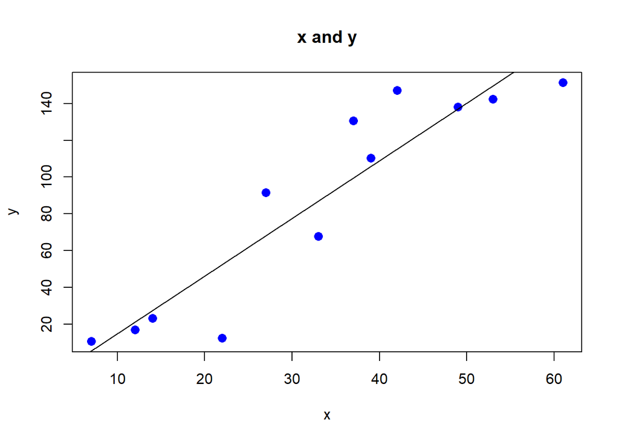

```r
plot(x, y, pch = 16, cex = 1.3, col = "blue", main = "x and y", xlab = "x", ylab = "y")
abline(lm(y~x))
```

Then, we used the least-squares prediction equation to predict y when x=40

```r
xi <- 40
yi <- -16.505 + 3.135*xi
cat("The predicted y is",yi)
```

```
## The predicted y is 108.895
```